# Application of Garman & Klass measures

Martina Chiesa and Matteo Zucca

## Project Advances Time Series

**Introduction:**

Financial Time Series Analysis of Intesa San Paolo Daily Prices

Data are downloaded from Yahoo Finance

## 1) Prepare Environment

### 1.1) Load libraries and auxiliary functions

```r
rm(list = ls())
suppressWarnings(suppressMessages(library(rugarch))) #fits Arima and Garch models
suppressWarnings(suppressMessages(library(forecast)))  #Rob Hyndman's package, contains Acf(.) function (it excludes first lag, acf(.) doesn't)
suppressWarnings(suppressMessages(library(xts)))       #xts object has some additional features rather than ts object (R's default)
suppressWarnings(suppressMessages(library(quantmod)))  #with getSymbols function we can download data

#setwd(getwd())  #other users should upload functions and data by changing the path
data.path = "C:\\Users\\Matteo\\Desktop\\Advanced Time Series\\Project\\Project TSA"
setwd(data.path)
source("SupportFunctions.R")
```

### 1.2) Download and store Data

Notice: section 1.2 should be executed only first time to download data, otherwise results will change day by day.

*symbol = “ISP.MI”* *x1 = getSymbols(Symbols = symbol,* *src = “yahoo”,* *auto.assign = FALSE,* *from = “2003-01-01”)*

*colnames(x1) = gsub(x = colnames(x1),* *pattern = paste0(symbol, “.”),* *replacement = “” )*

*x1 = data.frame(Date = index(x1), x1, check.names = FALSE)*

*x1[rowSums(is.na(x1)) > 0, ]; x1 = na.omit(x1); summary(x1) #remove NA’s records*

*write.table(x = x1, file = data.path, quote = FALSE, sep = “, na =”.”,* *row.names = FALSE, col.names = TRUE)*

### 1.3) Upload Data in the work environment and compute log-returns

**Upload Data in the work environment**

```r
setwd(data.path)
file.name = paste(data.path, "RawDataISP.csv", sep = "\\")
RawData = read.csv(file = file.name, header = T, sep = ",", dec = ".")

head(RawData); str(RawData); anyNA(RawData); summary(RawData); dim(RawData)
```

```
##         Date    Open    High     Low   Close   Volume Adjusted
## 1 2003-01-01 1.92583 1.92583 1.92583 1.92583        0 0.458497
## 2 2003-01-02 1.78255 1.96081 1.78255 1.94655 30426286 0.463430
## 3 2003-01-03 1.96972 2.02766 1.93853 1.98755 37824278 0.473191
## 4 2003-01-06 2.01429 2.05885 1.97864 2.04994 22839170 0.488045
## 5 2003-01-07 2.05885 2.05885 1.98309 1.99735 41620931 0.475525
## 6 2003-01-08 1.96972 1.99646 1.91625 1.92159 39776208 0.457488
```

```
## 'data.frame':    4599 obs. of  7 variables:
##  $ Date    : chr  "2003-01-01" "2003-01-02" "2003-01-03" "2003-01-06" ...
##  $ Open    : num  1.93 1.78 1.97 2.01 2.06 ...
##  $ High    : num  1.93 1.96 2.03 2.06 2.06 ...
##  $ Low     : num  1.93 1.78 1.94 1.98 1.98 ...
##  $ Close   : num  1.93 1.95 1.99 2.05 2 ...
##  $ Volume  : int  0 30426286 37824278 22839170 41620931 39776208 57802680 41522865 36877278 33957614 ...
##  $ Adjusted: num  0.458 0.463 0.473 0.488 0.476 ...
```

```
## [1] TRUE
```

```
##      Date                Open             High            Low
##  Length:4599        Min.   :0.8735   Min.   :0.919   Min.   :0.853
##  Class :character   1st Qu.:1.9698   1st Qu.:2.002   1st Qu.:1.936
##  Mode  :character   Median :2.4420   Median :2.470   Median :2.400
##                     Mean   :2.6678   Mean   :2.702   Mean   :2.631
##                     3rd Qu.:3.1560   3rd Qu.:3.182   3rd Qu.:3.113
##                     Max.   :5.8422   Max.   :5.866   Max.   :5.800
##                     NA's   :2        NA's   :2       NA's   :2
##      Close           Volume             Adjusted
##  Min.   :0.868   Min.   :        0   Min.   :0.3771
##  1st Qu.:1.969   1st Qu.: 55883369   1st Qu.:1.1137
##  Median :2.438   Median : 92706113   Median :1.4874
##  Mean   :2.666   Mean   :104956445   Mean   :1.4944
##  3rd Qu.:3.150   3rd Qu.:138295383   3rd Qu.:1.9014
##  Max.   :5.852   Max.   :711715261   Max.   :2.5898
##  NA's   :2       NA's   :2           NA's   :2
```

```
## [1] 4599    7
```

**Compute log-returns**

```r
RawDataFinal = data.frame(RawData,
                          log.return = c(NA, diff(log(RawData$Adjusted))), #log-returns
                          check.names = TRUE)
```

Note: we have to include a NA in order to match the dimension of dataframe and requirements set by garmanklass.measure function

**Remove NA**

```r
head(RawDataFinal)
```

```
##         Date    Open    High     Low   Close   Volume Adjusted  log.return
## 1 2003-01-01 1.92583 1.92583 1.92583 1.92583        0 0.458497          NA
## 2 2003-01-02 1.78255 1.96081 1.78255 1.94655 30426286 0.463430  0.01070160
## 3 2003-01-03 1.96972 2.02766 1.93853 1.98755 37824278 0.473191  0.02084376
## 4 2003-01-06 2.01429 2.05885 1.97864 2.04994 22839170 0.488045  0.03090850
## 5 2003-01-07 2.05885 2.05885 1.98309 1.99735 41620931 0.475525 -0.02598816
## 6 2003-01-08 1.96972 1.99646 1.91625 1.92159 39776208 0.457488 -0.03866880
```

```r
RawDataFinal = na.omit(RawDataFinal)
rownames(RawDataFinal) = 1 : nrow(RawDataFinal)
anyNA(RawDataFinal); dim(RawDataFinal)
```

```
## [1] FALSE
```

```
## [1] 4594    8
```

**Extract Variables**

```r
time = as.Date(x = RawDataFinal$Date)
close.price = RawDataFinal$Close
adj.price = RawDataFinal$Adjusted
nobs = NROW(adj.price)
```

Obs: adjusted prices are a transformation of close price that takes into account splits and dividends of the firms

## 2) Preliminary Analysis of Original Data

Purpose of this section is to prove that, when dealing with stock prices, modelling the mean isn’t possible since homoeskedasticity assumption doesn’t hold

**Plots**

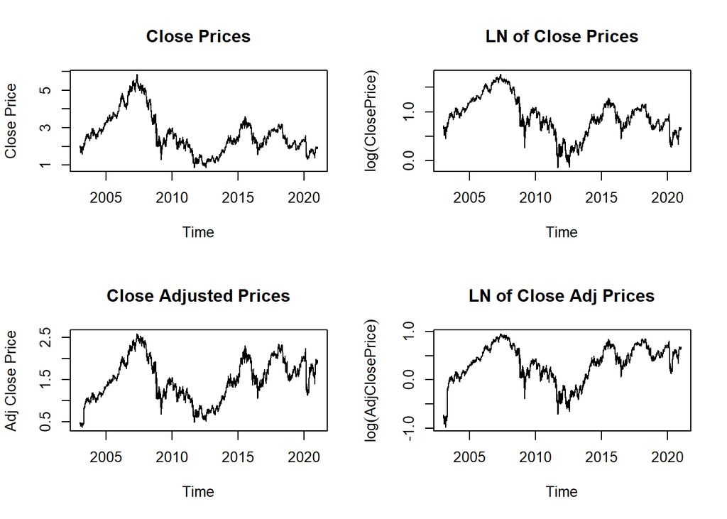

```r
par(mfrow = c(2,2))
plot(time, close.price, main = "Close Prices", xlab = "Time", ylab = "Close Price", type = "l")
plot(time, log(close.price), main = "LN of Close Prices", xlab = "Time", ylab = expression(log("ClosePrice")), type = "l")
plot(time, adj.price, main = "Close Adjusted Prices", xlab = "Time", ylab = "Adj Close Price", type = "l")
plot(time, log(adj.price),  main = "LN of Close Adj Prices", xlab = "Time", ylab = expression(log("AdjClosePrice")), type = "l")
```

```r
par(mfrow = c(1,1))
```

Notice:

- Serie of closing price isn’t stationary in mean
- We have clusters of variability (stylized fact of financial ts)
  - -> heteroschedasticty (either for log transform)
  - -> Arima relies on homoschedasticity

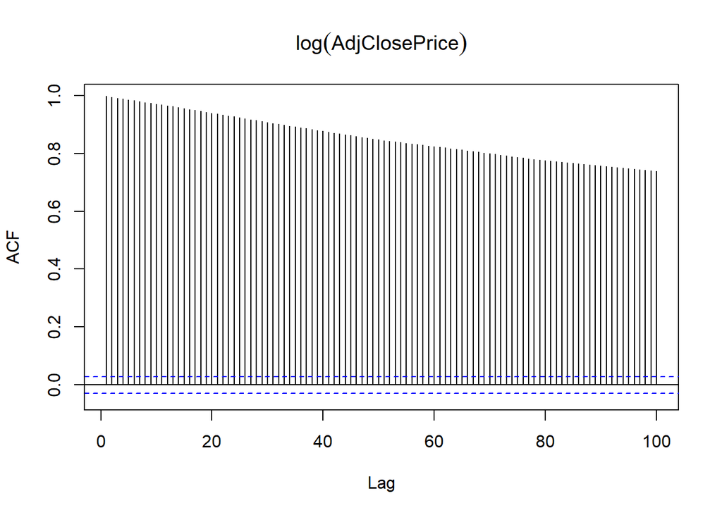

```r
Acf(log(adj.price), lag.max = 100, type = "correlation", main = expression(log("AdjClosePrice")))
```

Comment: decay of ACF is too slow -> serie is clearly non-stationary tests for Unit Root will lead to this conclusion (omitted)

Final Comments:

- Both series of close price and its log transform are non stationary and heteroskedastic
- Log scale allows to appreciate better the price changes. However it isn’t a variance-stabilizing transformation.
- In next session, we’ll use difference of logs to get a stationary (in mean) serie. In fact, this correspond to log-return

## 3) Preliminary analyses of log-returns

```r
y.ret = xts(x = 100 * RawDataFinal$log.return, order.by = time)
head(y.ret); summary(y.ret)  #values are logarithmic returns (in percentage)
```

```
##                 [,1]
## 2003-01-02  1.070160
## 2003-01-03  2.084376
## 2003-01-06  3.090850
## 2003-01-07 -2.598816
## 2003-01-08 -3.866880
## 2003-01-09  2.428692
```

```
##      Index                y.ret
##  Min.   :2003-01-02   Min.   :-26.05947
##  1st Qu.:2007-06-12   1st Qu.: -1.09802
##  Median :2011-12-15   Median :  0.00000
##  Mean   :2011-12-23   Mean   :  0.03174
##  3rd Qu.:2016-06-29   3rd Qu.:  1.17356
##  Max.   :2021-01-15   Max.   : 44.17825
```

**Plot of the serie**

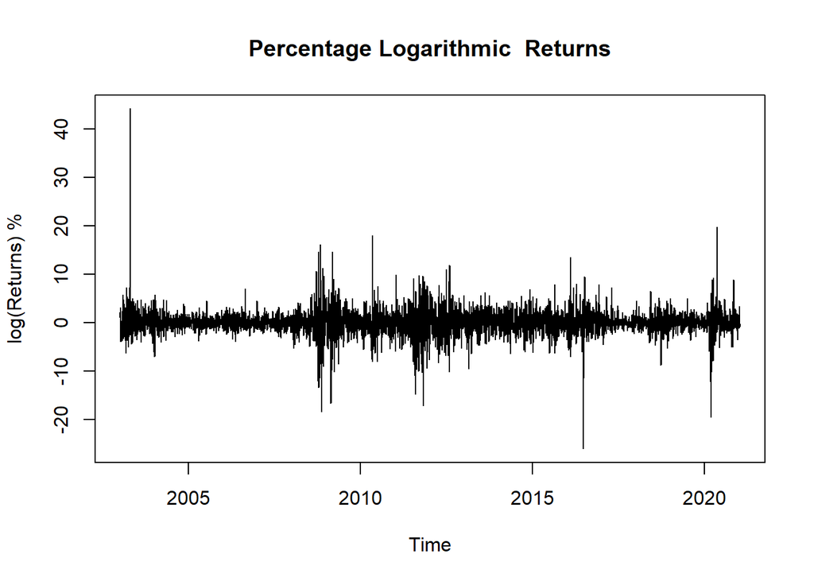

```r
plot(x = time, y = y.ret,
     main = "Percentage Logarithmic  Returns", xlab = "Time",
     ylab = paste(expression(log(Returns)),"%"), type = "l")
```

**ACF and PACF**

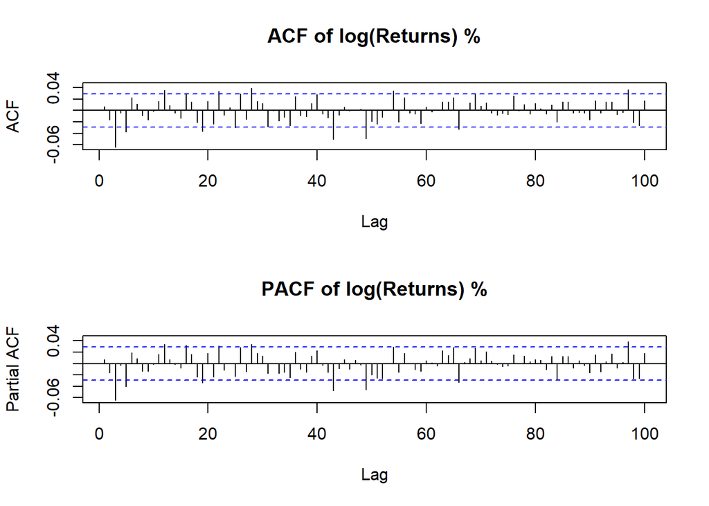

```r
par(mfrow = c(2,1))
Acf(x = y.ret, lag.max = 100, type = "correlation", main = paste("ACF of", expression(log(Returns)),"%"))
Acf(x = y.ret, lag.max = 100, type = "partial", main =  paste("PACF of", expression(log(Returns)),"%"))
```

```r
par(mfrow = c(1,1))
```

**Unconditional distribution**

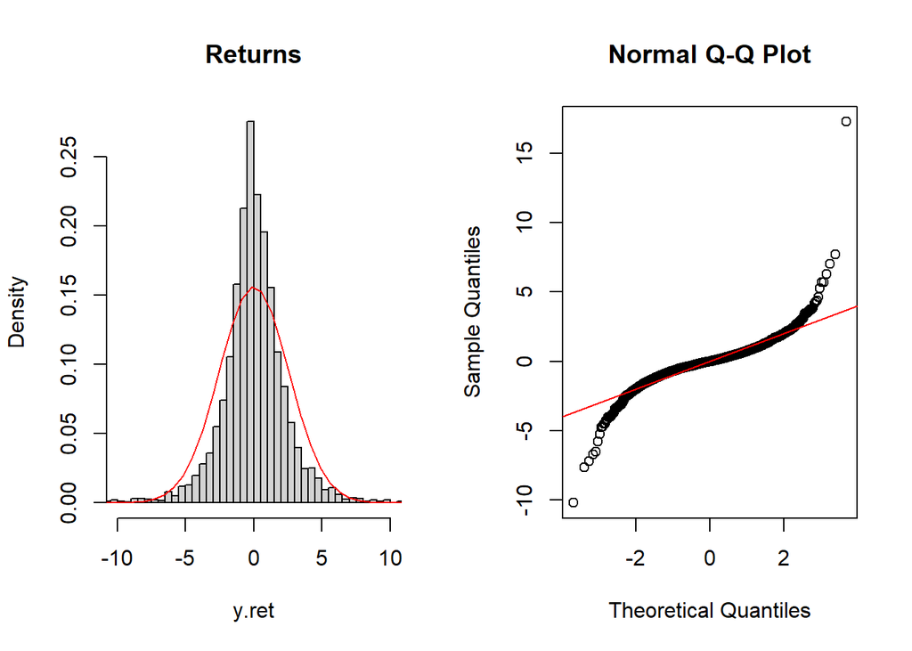

```r
par(mfrow = c(1,2))
hist(x = y.ret, xlim = c(-10, 10), breaks = 200, main = "Returns", freq = F)
norm_theo = seq(from = min(y.ret), to = max(y.ret)+1, length.out = 100)
lines(norm_theo, y = dnorm(norm_theo, 0, sd(y.ret)), col = "red")
qqnorm(y = scale(y.ret)); abline(a = 0, b = 1, col = "red")
```

```r
par(mfrow = c(1,1))
```

Comments:

- Daily log-returns move around a mean close to zero (similarly to a WN);
- There are periods with different variability around the mean (heteroskedasticity)

  This is a consequence of clusters of variability (stylized facts of financial TS)
- We have several outliers depending on exogenous shocks (e.g. economic crisis)
- From ACF, we can notice some lags that exceed the significance bands. However, in absolute value correlations aren’t that high.
- Normality is rejected: Distribution seems leptokurtic.

Despite these evidence, one may still think that log-return is a N-WN.

To exclude definitively this hypothesis: plot ACF of squared return.

It can be considered a (very) proxy measure for conditional variance, then if there’s serial autocorrelation it can not be a WN.

Furthermore, in a WN every transformation leads to a WN.

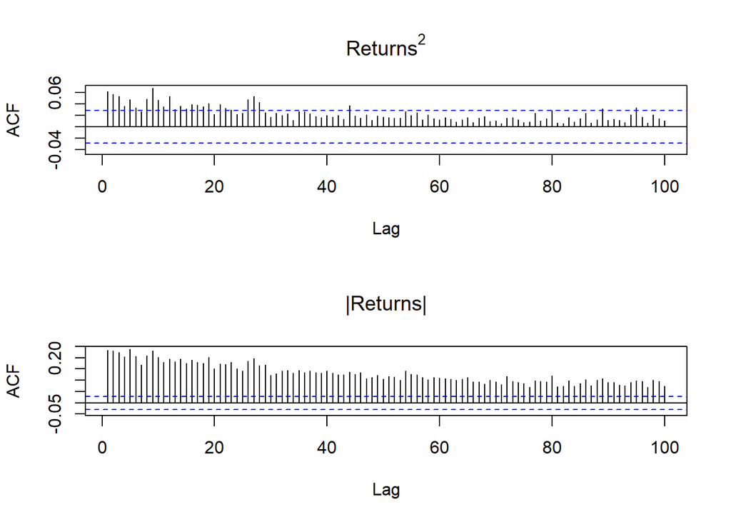

```r
par(mfrow = c(2,1))
Acf(y.ret^2, lag.max = 100, type = "correlation", main = expression(Returns^2))
Acf(abs(y.ret), lag.max = 100, type = "correlation", main = expression("|Returns|") )
```

```r
par(mfrow = c(1,1))
```

## 4) ARMA modelling (through rugarch package)

### 4.1) Fit Models

ARMA(0,0)-std AIC 4.396 BIC 4.4

ARMA(0,0)-norm AIC 4.716 BIC 4.718 -> Comment: worse, use standardized-t distrib for errors

ARMA(1,1)-std AIC 4.397 BIC 4.404 -> As expected, ICs don’t improve

```r
spec0 = arfimaspec(mean.model = list(armaOrder = c(2,1),
                                     include.mean = TRUE),
                   distribution.model = "std")
fit0 = arfimafit(spec = spec0, data = y.ret, solver = "solnp")

infocriteria(fit0)[1:2,]
```

```
##   Akaike    Bayes
## 4.393047 4.401448
```

### 4.2) Diagnostics on Residuals

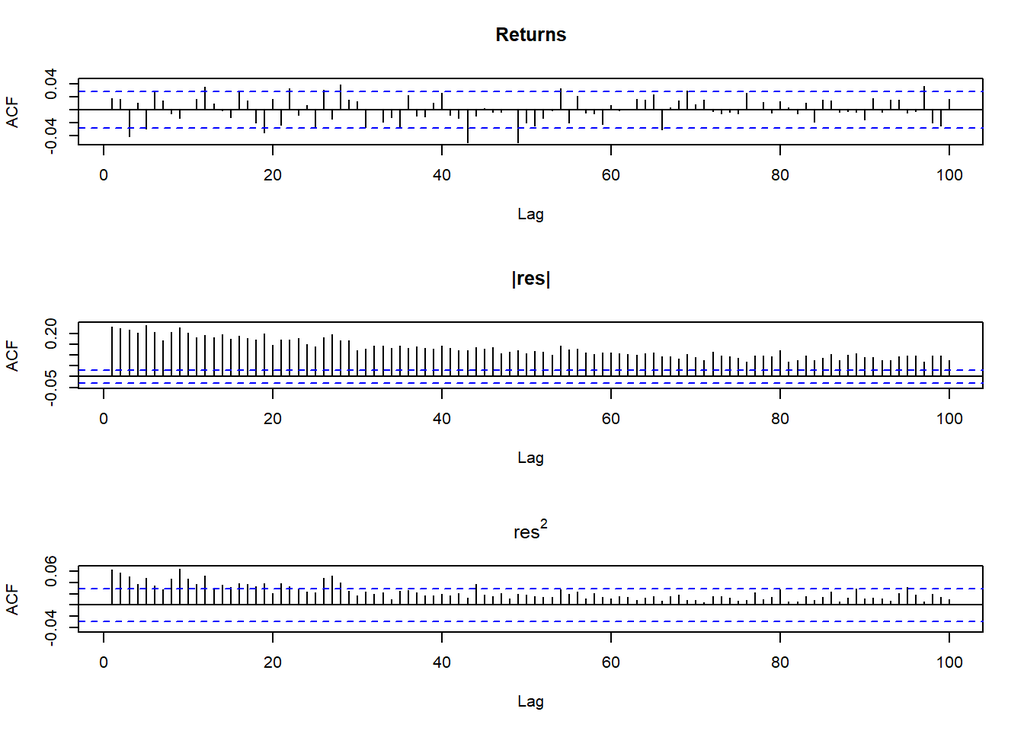

```r
res = as.numeric(residuals(fit0))
par(mfrow = c(3,1))
Acf(x = res, lag.max = 100, type = "correlation", main = "Returns")
Acf(x = abs(res), lag.max = 100, type = "correlation", main = "|res|")
Acf(x = res^2, lag.max = 100, type = "correlation", main = expression(res^2))
```

```r
par(mfrow = c(1,1))
```

Comments:

- Changing order of Arma and distribution of error doesn’t improve the problem of correlation of residuals.
- Residuals of an Arma model aren’t WN.
- Model for the mean isn’t adeguate.

## 5) GARCH modelling

In this section, we’ll explore various kinds of garch models.

Only pure-garch (no ARMA-Garch) since conditional mean is roughly constant (near zero).

### 5.1) Simple GARCH

**Fit and Statistics**

default is ARMA(1,1)+const -> exclude it (constant is in s-Garch too)

```r
spec1 = ugarchspec(
          variance.model = list(model = "sGARCH",
                                garchOrder = c(1,1)),  #often (1,1) is "enough"
          mean.model = list(armaOrder = c(0, 0),
                            include.mean = FALSE),
          distribution.model = "std")

fit1 = ugarchfit(spec = spec1, data = y.ret, solver = "solnp")  #Model: constant + garch

infocriteria(fit1)[1:2,]
```

```
##   Akaike    Bayes
## 4.191026 4.196626
```

```r
fit1@fit$robust.matcoef
```

```
##          Estimate  Std. Error   t value     Pr(>|t|)
## omega  0.04262439  0.01218779  3.497302 4.699893e-04
## alpha1 0.09371725  0.01360175  6.890086 5.575762e-12
## beta1  0.90336690  0.01256165 71.914666 0.000000e+00
## shape  5.90022898  0.59966231  9.839253 0.000000e+00
```

If the constrain doesn’t hold, the variance is infinite

**Diagnostic on Standardized Residuals**

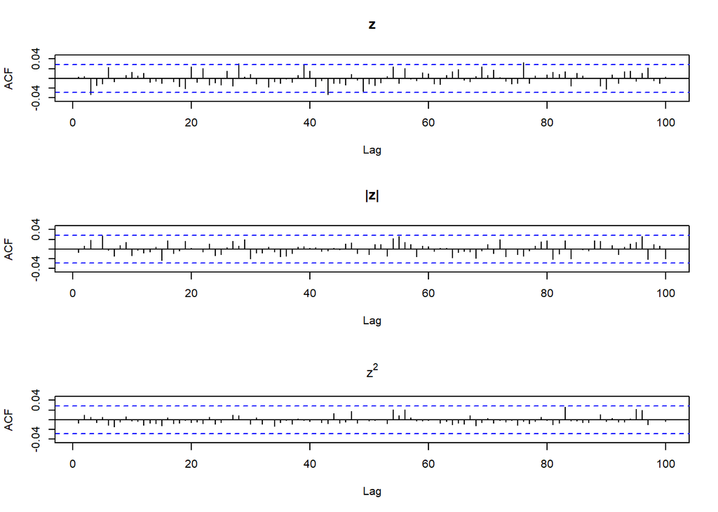

```r
fit = fit1
res.s.garch = fit@fit$z

par(mfrow = c(3,1))
Acf(res.s.garch,      lag.max = 100, type = "correlation", main = "z")
Acf(abs(res.s.garch), lag.max = 100, type = "correlation", main = "|z|")
Acf(res.s.garch^2,    lag.max = 100, type = "correlation", main = expression(z^2))
```

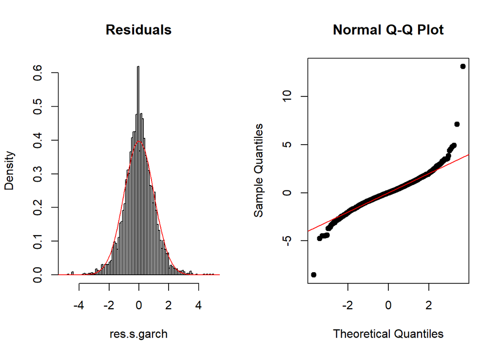

```r
par(mfrow = c(1,1))

par(mfrow = c(1,2))
hist(x = res.s.garch, xlim = c(-5, 5), breaks = 200, main = "Residuals", freq = FALSE)
norm_theo = seq(from = min(res.s.garch), to = max(res.s.garch)+1, length.out = 100)
lines(norm_theo, y = dnorm(norm_theo, 0, 1), col = "red")
qqnorm(y = res.s.garch, pch = 19); abline(a = 0, b = 1, col = "red")
```

```r
par(mfrow = c(1,1))
```

Comments:

- Simple-Garch may not be the best model but it has satisfying results (residuals NWN)
- Diagnostic on residuals doesn’t show any several problems. However we can notice the influence of outliers. This behaviour is common and well-studied in finance, e.g. the theory of Black Swan.

### 5.2) GJR-GARCH

We introduce a leverage parameter due to the stylized fact that conditional volatility is higher when returns are negative.

This can be seen as a sort of market turmoil.

**Fit and Statistics**

```r
spec2 = ugarchspec(
  variance.model = list(model = "gjrGARCH",
                        garchOrder = c(1,1)),
  mean.model = list(armaOrder = c(0, 0),
                    include.mean = FALSE),
  distribution.model = "std")


fit2 = ugarchfit(spec = spec2, data = y.ret, solver = "solnp")

infocriteria(fit2)[1:2,]
```

```
##   Akaike    Bayes
## 4.167053 4.174054
```

```r
fit2@fit$robust.matcoef
```

```
##           Estimate  Std. Error   t value     Pr(>|t|)
## omega  0.040085205 0.011247645  3.563876 3.654193e-04
## alpha1 0.009662833 0.007750323  1.246765 2.124836e-01
## beta1  0.924456204 0.012893862 71.697385 0.000000e+00
## gamma1 0.129266024 0.018542664  6.971276 3.140821e-12
## shape  6.368958088 0.696316585  9.146641 0.000000e+00
```

**Diagnostic on Residuals**

Note: Remember to use standardized residuals

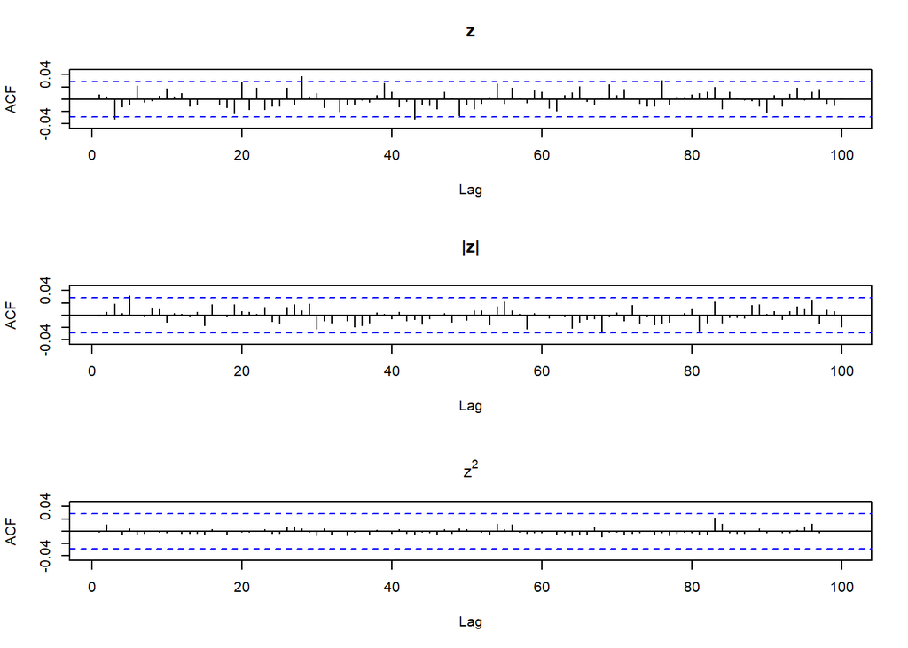

```r
fit = fit2
res.gjr.garch = fit@fit$z

par(mfrow = c(3,1))
Acf(res.gjr.garch,      lag.max = 100, type = "correlation", main = "z")
Acf(abs(res.gjr.garch), lag.max = 100, type = "correlation", main = "|z|")
Acf(res.gjr.garch^2,    lag.max = 100, type = "correlation", main = expression(z^2))
```

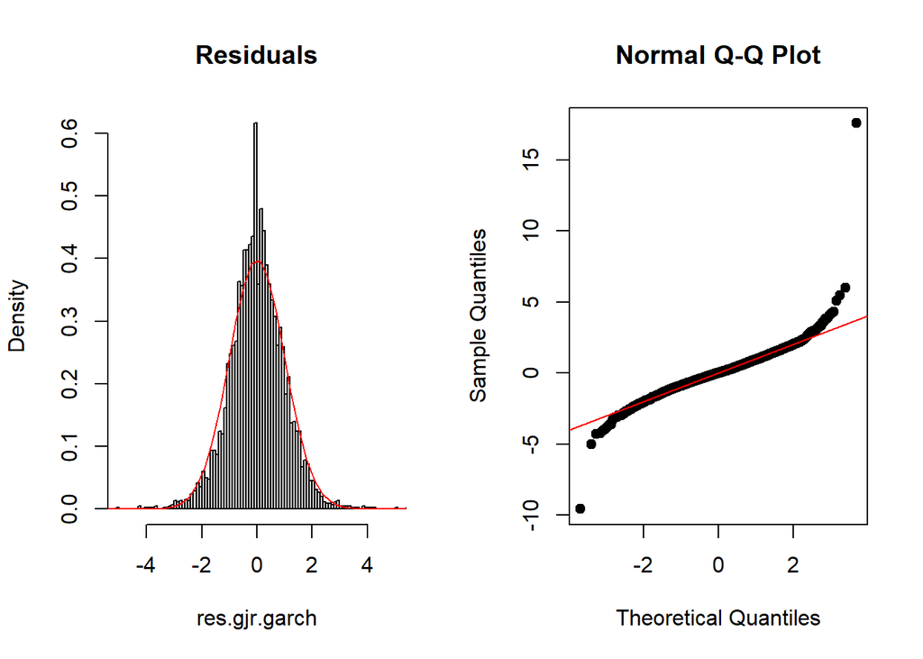

```r
par(mfrow = c(1,1))

par(mfrow = c(1,2))
hist(x = res.gjr.garch, xlim = c(-5, 5), breaks = 200, main = "Residuals", freq = FALSE)
norm_theo = seq(from = min(res.gjr.garch), to = max(res.gjr.garch)+1, length.out = 100)
lines(norm_theo, y = dnorm(norm_theo, 0, 1), col = "red")
qqnorm(y = res.gjr.garch, pch = 19); abline(a = 0, b = 1, col = "red")
```

```r
par(mfrow = c(1,1))
```

Comments:

- GJR-Garch has slightly better diagnostic than s-Garch
- Does it worths an higher complexity (leverage parameter)? Answer has to be based on error measures.

### 5.3) Further developments

Literature proposed decades of garch models starting from 80’s. For example: T-Garch, E-Garch, i-Garch and the entire family of f-Garch. They differ by several aspects.

However often the simple-Garch(1,1) has satisfying results and increasing complexity doesn’t worth it.

## 6) Forecasting (Ex-Post)

Notice:

- We assume Garman-Klass measures as a less noisy proxy than squared return for volatility at time t.
- We don’t perform any kind of external validation. As a consequence, the error may be underestimated.

### 6.1) Calculate G-K volatility and Analyze them

```r
y.gk = garmanklass.measure(data = RawDataFinal, volatility = TRUE) * 100  #variance, not volatility
head(y.gk)
```

```
## [1]       NA 3.495535 2.961076 2.035371 2.834207 5.427757
```

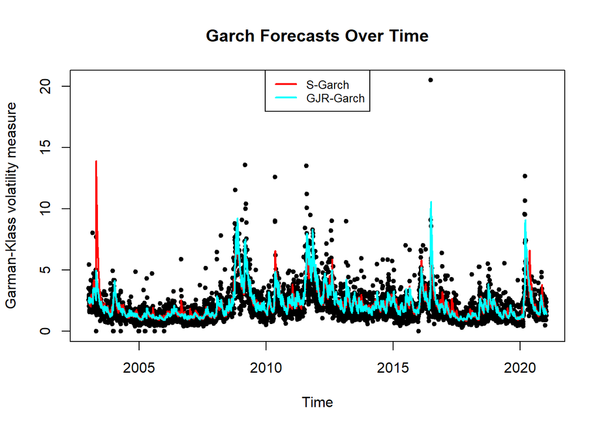

```r
y.gk[1] = sd(y.ret)

y.s.garch = fit1@fit$sigma
y.gjr.garch = fit2@fit$sigma

ylim.temp = range(max(y.s.garch), max(y.gjr.garch), max(y.gk),
                  min(y.s.garch), min(y.gjr.garch),  min(y.gk))

plot(x = time, y = y.gk,
     ylim = ylim.temp, pch = 20, type = "p",
     ylab = "Garman-Klass volatility measure", xlab = "Time",
     main="Garch Forecasts Over Time")


lines(time, y.s.garch, col = "red", lwd = 2)
lines(time, y.gjr.garch, col = "cyan", lwd = 2)
legend("top", legend=c("S-Garch","GJR-Garch"),
       col = c("red","cyan"), lty = c(1,1), cex = 0.8,ncol = 1,lwd = 2)
```

### 6.2) Calculate Error Measures

**Set Naive Model**

We assume as naive the unconditional variance or the unconditional st.dev (for volatility)

```r
naive.vol = sd(y.ret)
naive.var = naive.vol^2
```

**Computer Error Measures**

```r
errors = data.frame(
  measure = rep(c("Volatility", "Variance"), each = 2),
  model = rep(c("S-Garch", "GJR-Garch"), times = 2),
  rbind(
        error.measures(y = y.gk,   fit = y.s.garch,   naive = naive.vol),
        error.measures(y = y.gk,   fit = y.gjr.garch,   naive = naive.vol),
        error.measures(y = y.gk^2, fit = y.s.garch^2, naive = naive.var),
        error.measures(y = y.gk^2, fit = y.gjr.garch^2, naive = naive.var)
        )
  )

errors
```

```
##      measure     model         ME       MAE      RMSE     ScMAE    ScRMSE
## 1 Volatility   S-Garch -0.1967724 0.7228019  1.154427 0.6387501 0.7945441
## 2 Volatility GJR-Garch -0.1718404 0.6892103  1.057953 0.6090647 0.7281451
## 3   Variance   S-Garch -0.5964056 4.3690612 12.583223 0.7558647 1.0050975
## 4   Variance GJR-Garch -0.5377101 4.1256162 11.134860 0.7137478 0.8894081
```

Comments:

- Both models, compared to naive, performs well on predicting the volatility.
- GJR-Garch allows a reduction of 7 percentage point w.r.t. S-GARCH in Scaled RMSE.
- S-Garch doesn’t works well on predicting the conditional variance if compared to naive model. However with the leverage parameter we can improve this inefficiency.

End of Project Advances Time Series - Martina Chiesa and Matteo Zucca